# Introduction to Meta-analysis

Daniel W.A. Noble

2022-10-02

## **What is meta-analysis and why do we do it?**

Meta-analysis is the gold-standard for research synthesis across all disciplines. Formally, it is defined as a set of:

> Statistical methods and techniques for aggregating, summarizing, and drawing inferences from collections of studies

We synthesise studies to gain broader insights into the efficacy of treatment effects and / or relationships between variables. In biology, we are also dealing with many different populations and species. As such, we’re not just interested in understanding ‘what the overall effect’ actually is (in fact, we may not even care in many cases), but we are mainly focused on attempting to understand what factors (e.g., biological, methodological) explain variation in effects (Noble et al. 2022; Lajeunesse 2010; Gurevitch et al. 2018). A key part of meta-analysis is quantifying variability in effects across studies, or what is referred to as ‘heterogeneity’ in meta-analysis (O’Dea et al. 2021; Nakagawa and Santos 2012; Borenstein 2019; Nakagawa et al. 2017; Gurevitch et al. 2018).

Think about it this way, in a meta-analysis we want to know what the average effect is across studies to tell us what the mean effect in the population is likely to be. We also want to understand why one experiment gives a different effect size (e.g., Cohen’s d) then the same experiment using a different sample.

## **Effect Size Statistics are the Key Currency in Meta-analysis**

Meta-analysis is a way to synthesise effect size statistics (i.e., a statistic such as Cohen’s *d*) using a special type of mixed effects model that accounts for our sampling uncertainty in each effect estimate. Effect size statistics are the data we use to build models.

Effect size statistics can vary but they all have a few key things in common. First, the effect size must be comparable across studies. This means that they must be placed on the same scale so that they can be aggregated. Second, we must be able to estimate the sampling variance for a given effect size. As you’re well aware, the statistic (effect size) we want to synthesise has uncertainty associated with it because of sampling variability – the standard error around a mean, for example, is sampling error. In meta-analysis we use this sampling error (more specifically sampling variance) to decrease the uncertainty in our mean effect size. There are lots of different effect sizes out there, some familiar ones are in Table 1.

Table 1: **Common effect sizes used throughout meta-analyses and their associated sampling variances. Examples on when they might be used are also provided**. Abbreviations are as follows: M: mean; SD: standard deviation; N: sample size

[output not shown]

a $$Notes: J = 1 - \frac{3}{4\left(N_{1} + N_{2} - 2\right) - 1}$$ ; a $$SD_{p} = \sqrt \frac{\left( N_{1}-1 \right)SD_{1}^2 + \left( N_{2}-1 \right)SD_{2}^2}{N_{1} + N_{2} - 2}$$

Many studies in ecology and evolution meta-analyse the mean, but more commonly standardised effect size statistics are used like the log response ratio (big in Ecology), the standardised mean difference (i.e., Cohen’s d, Hedges’ g – you already were exposed to Cohen’s d in Eric’s workshops!), and correlation coefficients. In the next section we’re going to dwell on the effect size statistics, and more specifically their sampling variances, a little more to make sure we understand exactly what these equations are saying.

## **Understanding Sampling Variances**

But wait, what do we really mean when we say sampling variance of an effect size statistic? It’s all fine that we have equations in Table 1 to calculate this for various statistics, but they also look scary, and I don’t actually know what they are really telling me about the statistic in question!

If that’s what your thinking that is totally normal. Don’t fret! We’re going to try to breakdown exactly what we mean by sampling variance and show that these equations are nothing more then simple little shortcuts for us to estimate the sampling uncertainty of effect size statistic.

Let’s return to what we learnt at the beginning the semester about sampling distributions. In order to understand sampling variance we need to do a thought experiment. When we collect sample sizes and statistics from a paper to calculate an effect size statistic and it’s sampling variance we really need to remember that this is a statistic that is provided from a single sampling event. It’s estimated with uncertainty – potentially lots of uncertainty of the sample sizes are small.

Now, let’s assume that we take that study and turn it into a simple simulation so that we can endlessly repeat the experiment to create a sampling distribution of the statistic – the variance in that sampling distribution is in fact that sampling variance for the effect statistic.

Lets apply this thinking to estimating a very simple statistic and it’s sampling variance described in Table 1, the mean. To do this, we need to imagine ourselves going out and sampling from a population many, many times; taking the same size of sample each time. Again, we know the population has a ‘true’ mean, but we are trying to estimate that from a small sample so we know it will be off each time we sample. Enough talking, lets code this scenario. For ease of understanding it’s good to apply a loop here just to wrap your head about what’s going on.

```r
# First lets set up some parameters. We'll take 20 samples from a population
# with a mean of 10.8 and a sd of 0.988
nsim = 10000
n = 20
mean = 10.8
sd = 0.988

# Now, lets create an empty vector to store our sample mean. We'll then loop,
# sampling 20 from the population described above but we'll take 10000 samples
# so we can get a fairly accurate estimate of the 'true' mean and it's sampling
# error
means <- c()

for (i in 1:nsim) {
    sample <- rnorm(n, mean = mean, sd = sd)
    means <- c(means, mean(sample))
}
```

Let’s now have a look at our sampling distribution of means that we calculated for each of our 10000 samples:

[figure not shown]

```r
# Now lets plot the sampling distribution. We'll show the real, true mean,
# 10.8, and the actual mean of the sampling distribution.
ggplot2::ggplot(tibble(means), aes(x = means)) + geom_histogram(binwidth = 0.02) +
    geom_vline(xintercept = 10.8, col = "red") + geom_vline(xintercept = mean(means),
    col = "blue", linetype = 2)
```

Great. We can see that our mean of the sampling distribution matches our true mean, just like we expect.

Now, how do we calculate the sampling error? From Table 1 we can see that the sampling variance is calculated as $\frac{SD^2}{N}$. We know that the sd is approximately 0.988 and we have a sample size of `n` so that means our sampling variance is expected to be approximately 0.05 (`0.988^2 / n`).

Remember, we are estimating the sampling variance for the mean effect statistic in our simulation. Given that we have the sampling distribution for the mean estimate we can calculate this directly from the sampling distribution by simply calculating the variance of the distribution. Let’s do that:

```r
# Calculate the mean sampling variance

tab1 <- data.frame(Approach = c("Analytical", "Simulation"), `Sampling Variance` = c(0.988^2/n,
    var(means)), check.names = FALSE)
flextable(tab1)
```

| Approach | Sampling Variance |
| --- | --- |
| Analytical | 0.049 |
| Simulation | 0.050 |

There you have it. When you see the sampling variance equations in Table 1 all you need to remember is that these are shortcuts to doing the simulations we have just done above under the specific sampling scenario that we created in a study.

I’m going to assume here that you’re super critical and you don’t believe me (good!) so lets do this again with a more complicated effect size statistic, the log response ratio.

```r
# First, lets set up some parameters. We'll take 20 samples from two
# populations that we are interested in contrasting (say a control and
# treatment group). The control group has a true mean of 10.8 and a sd of
# 0.988, whereas the treatment group has a true mean of 5.5 with a sd of 1.2.
# What that means is, effectively, the log response ratio is: log(10.8/5.5), or
# 0.67, because we are interesting in contrasting the two groups
nsim = 10000
n = 20
mean1 = 10.8
sd1 = 0.988
mean2 = 5.5
sd2 = 1.2

# Now, lets create an empty vector to store our log response ratio effect size
# statistic that we calculate from our samples. We'll then loop, sampling 20
# from both groups and calculating the log response ratio, and we'll do this
# 10000 samples so we can get a fairly accurate estimate of the log response
# ratio statistic.
lnrr <- c()

for (i in 1:nsim) {
    sample1 <- rnorm(n, mean = mean1, sd = sd1)
    sample2 <- rnorm(n, mean = mean2, sd = sd2)
    lnrr <- c(lnrr, log(mean(sample1)/mean(sample2)))
}
```

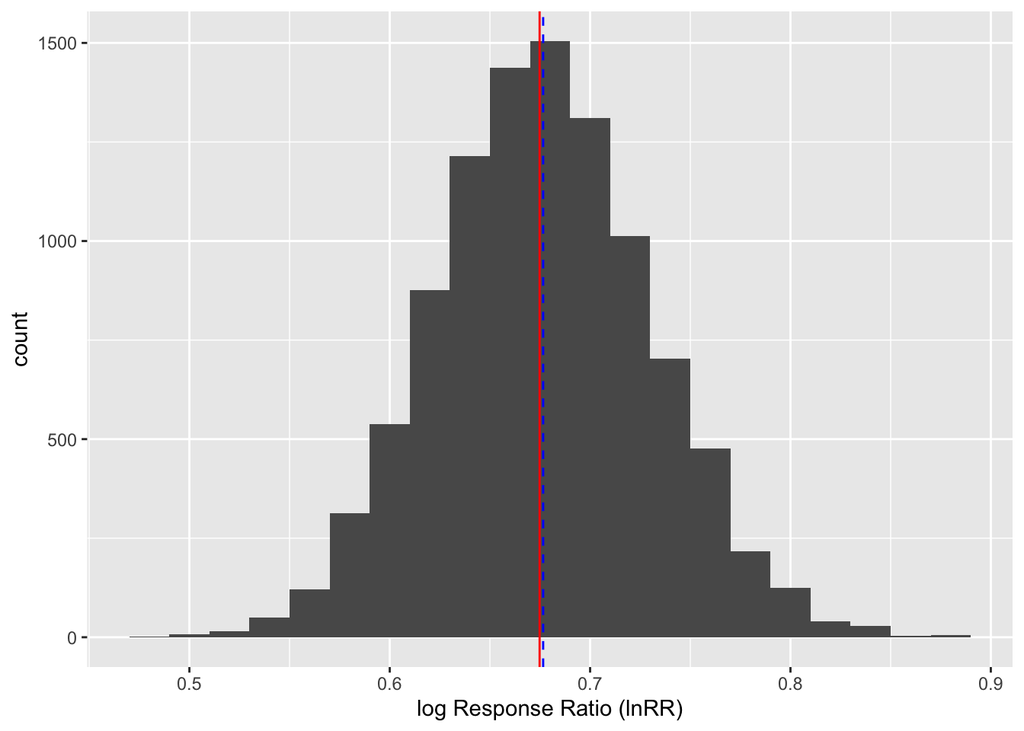

```r
# Now lets plot the sampling distribution. We'll show the real, true mean,
# 0.67, and the actual mean of the sampling distribution.
ggplot2::ggplot(tibble(lnrr), aes(x = lnrr)) + geom_histogram(binwidth = 0.02) +
    geom_vline(xintercept = log(10.8/5.5), col = "red") + geom_vline(xintercept = mean(lnrr),
    col = "blue", linetype = 2) + labs(x = "log Response Ratio (lnRR)")
```

Table 1 above tells us what the sampling variance should be for this situation. We can calculate it ourselves from the equation and see if it matches the variance of the distribution:

```r
# We know the 'true' values so we can use them to calculate what the sampling
# variance for this specific situation should be.
sv_lnrr <- (sd1^2/(mean1^2 * n)) + (sd2^2/(mean2^2 * n))

# We just did a simple simulation of the situation where we only calculate the
# effect size statistic, now lets see what the sampling variance is of the lnRR
# sampling distribution that we calculated.
samp_dist_lnRR <- var(lnrr)

# Create a table to contrast these a little more clearly
tab <- data.frame(Approach = c("Analytical", "Simulation"), `Sampling Variance` = c(sv_lnrr,
    samp_dist_lnRR), check.names = FALSE)
flextable(tab)
```

| Approach | Sampling Variance |
| --- | --- |
| Analytical | 0.0028 |
| Simulation | 0.0029 |

What I recommend doing now is to play around with `n`. Change it and rerun the code. How does the sampling variance change?

## **How does meta-analysis work?**

Meta-analysis quantitatively aggregates effect size data collected from existing research and ‘controls’ for the sampling variability in the process. Why would we want to account for a given study’s sampling variance? We want to do this because studies vary greatly in their sample size, and thus their power, to detect effects. As meta-analysts we want to weight effect sizes from studies with higher power more in an analysis. These studies are more likely to be ‘correct’.

We can effectively think of a meta-analysis as a weighted regression model with the weights being the inverse sampling variance for each effect size. Weights are calculated differently depending on the meta-analytic model in question. The following video by [Marc Lajeunesse](http://lajeunesse.myweb.usf.edu) articulates a little more clearly why weighting in meta-analysis is so important and overviews a few of the types of models that we covered in the tutorial.

[video not shown]

## **Getting Ready for Friday’s Workshop: Meta-analysis with `metafor`**

During Friday’s workshop we will make use of the `metafor` package (Viechtbauer 2010). It is the most widely used meta-analytic package in biology. It can calculate effect size statistics for you, fit an incredible diversity of meta-analytic models, explore and ‘correct’ (as best as one can anyway) for publication biases and a whole lot more. To get familiar with `metafor` have a look at Wolfgang’s `UseR` talk below, which will help you get a sense of how it works.

[video not shown]

## **References**

Borenstein, Micheal. 2019. “Heterogenity in Meta-Analysis.” In, edited by Harris Cooper, Larry V. Hedges, and Jeffrey C. Valentine, 3rd Edition, 454–66. New York: Russell Sage Foundation.

Gurevitch, Jessica, Julia Koricheva, Shinichi Nakagawa, and Gavin Stewart. 2018. “Meta-Analysis and the Science of Research Synthesis.” *Nature* 555: 176–82.

Lajeunesse, M. J. 2010. “Achieving Synthesis with Meta-Analysis by Combining and Comparing All Available Studies.” *Ecology* 91 (9): 2561–64.

Nakagawa, Shinichi, Daniel W. A. Noble, Alistair M. Senior, and Malgorzata Lagisz. 2017. “Meta-Evaluation of Meta-Analysis: Ten Appraisal Questions for Biologists.” *BMC Biology*, 15–18, DOI 10.1186/s12915-017-0357-7.

Nakagawa, Shinichi, and Eduardo SA Santos. 2012. “Methodological Issues and Advances in Biological Meta-Analysis.” *Evolutionary Ecology* 26 (5): 1253–74.

Noble, Daniel W. A., Patrice Pottier, Malgorzata Lagisz, Samantha Burke, Szymon M. Drobniak, Rose E. O’Dea, and Shinichi Nakagawa. 2022. “Meta-Analytic Approaches and Effect Sizes to Account for ‘Nuisance Heterogeneity’ in Comparative Physiology.” *Journal of Experimental Biology* 225: jeb243225.

O’Dea, Rose E., Malgorzata Lagisz, Michael D. Jennions, Julia Koricheva, Daniel W. A. Noble, Timothy H. Parker, Jessica Gurevitch, et al. 2021. “Preferred Reporting Items for Systematic Reviews and Meta-Analyses in Ecology and Evolutionary Biology: A PRISMA Extension.” *Biological Reviews* doi: 10.1111/brv.12721.

Viechtbauer, W. 2010. “Conducting Meta-Analyses in r with the Metafor Package.” *Journal of Statistical Software* 36 (3): 1–48. URL: https://www.jstatsoft.org/v36/i03/.